# dplyr, tidyr : Coder (presque) comme on parle

[figure not shown]

Joël Gombin  
CHERPA-IEP Aix / CURAPP-Uni. de Picardie  
[R User Group Aix-Marseille](http://www.meetup.com/http://www.meetup.com/fr-FR/R-user-group-Aix-Marseille//)  
28 janvier 2016

### Une nouvelle génération de packages

AKA le [“Hadleyverse”](https://github.com/hadley/)

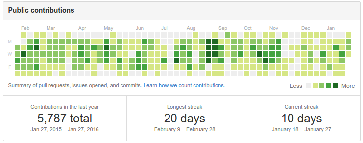

Slides at http://joelgombin.fr/rugmars/dplyr.html

### Une nouvelle génération de packages

[`dplyr`](https://github.com/hadley/dplyr), [`tidyr`](https://github.com/hadley/tidyr), [`ggplot2`](https://github.com/hadley/ggplot2) bien sûr, [`ggvis`](https://github.com/rstudio/ggvis), [`httr`](https://github.com/hadley/httr), [`rvest`](https://github.com/hadley/rvest), readr, etc.

### Des packages centrés sur le point fort de R

`dplyr` et `tidyr` sont des réimplémentations de `plyr` et `reshape` spécialisés sur les dataframes.

### Une syntaxe renouvelée

Deux principes :

- l'usage de verbes - c'est-à-dire une fonction qui prend un data.frame comme premier argument (`group_by`, `summarise`, `select`, `filter`, `arrange`, `spread`, `gather`)
- l'usage du pipe `%>%` (qui se lit “then” et vient du package [`magrittr`](https://github.com/smbache/magrittr))

```r
library(nycflights13)
library(dplyr)
flights
```

```
Source: local data frame [336,776 x 16]

    year month   day dep_time dep_delay arr_time arr_delay carrier tailnum
   (int) (int) (int)    (int)     (dbl)    (int)     (dbl)   (chr)   (chr)
1   2013     1     1      517         2      830        11      UA  N14228
2   2013     1     1      533         4      850        20      UA  N24211
3   2013     1     1      542         2      923        33      AA  N619AA
4   2013     1     1      544        -1     1004       -18      B6  N804JB
5   2013     1     1      554        -6      812       -25      DL  N668DN
6   2013     1     1      554        -4      740        12      UA  N39463
7   2013     1     1      555        -5      913        19      B6  N516JB
8   2013     1     1      557        -3      709       -14      EV  N829AS
9   2013     1     1      557        -3      838        -8      B6  N593JB
10  2013     1     1      558        -2      753         8      AA  N3ALAA
..   ...   ...   ...      ...       ...      ...       ...     ...     ...
Variables not shown: flight (int), origin (chr), dest (chr), air_time
  (dbl), distance (dbl), hour (dbl), minute (dbl).
```

### Permet une lecture plus aisée du code

```r
flights %>%
  filter(carrier %in% "UA")
```

```
Source: local data frame [58,665 x 16]

    year month   day dep_time dep_delay arr_time arr_delay carrier tailnum
   (int) (int) (int)    (int)     (dbl)    (int)     (dbl)   (chr)   (chr)
1   2013     1     1      517         2      830        11      UA  N14228
2   2013     1     1      533         4      850        20      UA  N24211
3   2013     1     1      554        -4      740        12      UA  N39463
4   2013     1     1      558        -2      924         7      UA  N29129
5   2013     1     1      558        -2      923       -14      UA  N53441
6   2013     1     1      559        -1      854        -8      UA  N76515
7   2013     1     1      607         0      858       -17      UA  N53442
8   2013     1     1      611        11      945        14      UA  N532UA
9   2013     1     1      623        -4      933         1      UA  N459UA
10  2013     1     1      628        -2     1016        29      UA  N33289
..   ...   ...   ...      ...       ...      ...       ...     ...     ...
Variables not shown: flight (int), origin (chr), dest (chr), air_time
  (dbl), distance (dbl), hour (dbl), minute (dbl).
```

### Permet une lecture plus aisée du code

```r
flights %>%
  filter(carrier %in% "UA") %>%
  select(year, month, day, carrier, origin, dest)
```

```
Source: local data frame [58,665 x 6]

    year month   day carrier origin  dest
   (int) (int) (int)   (chr)  (chr) (chr)
1   2013     1     1      UA    EWR   IAH
2   2013     1     1      UA    LGA   IAH
3   2013     1     1      UA    EWR   ORD
4   2013     1     1      UA    JFK   LAX
5   2013     1     1      UA    EWR   SFO
6   2013     1     1      UA    EWR   LAS
7   2013     1     1      UA    EWR   MIA
8   2013     1     1      UA    JFK   SFO
9   2013     1     1      UA    LGA   IAH
10  2013     1     1      UA    EWR   LAX
..   ...   ...   ...     ...    ...   ...
```

### Permet une lecture plus aisée du code

```r
flights %>%
  group_by(year, month, day) %>%
  summarise(delay = mean(arr_delay, na.rm = TRUE))
```

```
Source: local data frame [365 x 4]
Groups: year, month [?]

    year month   day      delay
   (int) (int) (int)      (dbl)
1   2013     1     1 12.6510229
2   2013     1     2 12.6928879
3   2013     1     3  5.7333333
4   2013     1     4 -1.9328194
5   2013     1     5 -1.5258020
6   2013     1     6  4.2364294
7   2013     1     7 -4.9473118
8   2013     1     8 -3.2275785
9   2013     1     9 -0.2642777
10  2013     1    10 -5.8988159
..   ...   ...   ...        ...
```

### Permet une lecture plus aisée du code

```r
flights %>%
  group_by(paste(year, month, day, sep = "-")) %>%
  summarise(delay = mean(arr_delay, na.rm = TRUE)) %>%
  arrange(desc(delay))
```

```
Source: local data frame [365 x 2]

   paste(year, month, day, sep = "-")    delay
                                (chr)    (dbl)
1                            2013-3-8 85.86216
2                           2013-6-13 63.75369
3                           2013-7-22 62.76340
4                           2013-5-23 61.97090
5                           2013-7-10 59.62648
6                           2013-9-12 58.91242
7                            2013-7-1 58.28050
8                          2013-12-17 55.87186
9                            2013-8-8 55.48116
10                          2013-12-5 51.66625
..                                ...      ...
```

### Permet une lecture plus aisée du code

```r
flights %>%
  mutate(date = paste(year, month, day, sep = "-")) %>%
  group_by(date) %>%
  summarise(delay = mean(arr_delay, na.rm = TRUE)) %>%
  arrange(desc(delay))
```

```
Source: local data frame [365 x 2]

         date    delay
        (chr)    (dbl)
1    2013-3-8 85.86216
2   2013-6-13 63.75369
3   2013-7-22 62.76340
4   2013-5-23 61.97090
5   2013-7-10 59.62648
6   2013-9-12 58.91242
7    2013-7-1 58.28050
8  2013-12-17 55.87186
9    2013-8-8 55.48116
10  2013-12-5 51.66625
..        ...      ...
```

### Résumé des principaux verbes

- `filter` : subset en fonction de conditions logiques
- `select` : sélectionne certaines variables seulement
- `arrange` : trie le data.frame selon certaines variables
- `mutate` : crée de nouvelles variables
- `group_by` : crée des groupes
- `summarise` : agrège un dataframe ou un groupe en une ligne

### Et aussi...

- `tally`/`count` : tabulation (compte les lignes)
- `do` : permet de faire n'importe quelle opération sur des groupes (ex : `lm`)
- sélection aisée de variables : `data %>% select(varA:varZ)` ou `data %>% select(-varB)` ou encore `data %>% select(starts_with("var"))`
- joins (en style SQL)
- `bind_rows` / `bind_cols`
- `sample_n()` et `sample_frac`
- écrit en C++, donc *rapide*

### Les tables peuvent venir de sources différentes

- de `datatable`
- et SURTOUT de [bases de données](https://cran.r-project.org/web/packages/dplyr/vignettes/databases.html) (SQL) !
- mais aussi [Spark](https://github.com/RevolutionAnalytics/dplyr-spark), ImpalaDB, etc.

```r
my_db <- src_sqlite("my_db.sqlite3", create = T)
flights_sqlite <- copy_to(my_db, flights, temporary = TRUE, indexes = list(
  c("year", "month", "day"), "carrier", "tailnum"))

flights_sqlite %>%
  filter(origin == "JFK") %>%
  arrange(desc(distance))
```

```
Source: sqlite 3.8.6 [my_db.sqlite3]
From: flights [111,279 x 16]
Filter: origin == "JFK"
Arrange: desc(distance)

    year month   day dep_time dep_delay arr_time arr_delay carrier tailnum
   (int) (int) (int)    (int)     (dbl)    (int)     (dbl)   (chr)   (chr)
1   2013     1     1      857        -3     1516       -14      HA  N380HA
2   2013     1     2      909         9     1525        -5      HA  N380HA
3   2013     1     3      914        14     1504       -26      HA  N380HA
4   2013     1     4      900         0     1516       -14      HA  N384HA
5   2013     1     5      858        -2     1519       -11      HA  N381HA
6   2013     1     6     1019        79     1558        28      HA  N385HA
7   2013     1     7     1042       102     1620        50      HA  N385HA
8   2013     1     8      901         1     1504       -26      HA  N389HA
9   2013     1     9      641      1301     1242      1272      HA  N384HA
10  2013     1    10      859        -1     1449       -41      HA  N388HA
..   ...   ...   ...      ...       ...      ...       ...     ...     ...
Variables not shown: flight (int), origin (chr), dest (chr), air_time
  (dbl), distance (dbl), hour (dbl), minute (dbl).
```

### Oui, mais...

- on ne peut pas programmer avec `dplyr` ?
  - si : avec les fonctions “standard evaluation” du type `select_`
- il n'y a pas d'autocomplétion dans Rstudio ?
  - si !
- Il n'y a pas de parallélisation possible ?
  - Pas dans `dplyr` mais en travail : multidplyr

### tidyr, un complément logique de dplyr

`tidyr` est à `dplyr` ce que `reshape` est à `plyr`.

Deux (et deux seulement !) fonctions :

- `gather` (format large -> format long)
- `spread` (format long -> format large)

avec un système clé-valeur.

```r
library(tidyr)
messy <- data.frame(
  name = c("Wilbur", "Petunia", "Gregory"),
  a = c(67, 80, 64),
  b = c(56, 90, 50)
  )

messy %>%
  gather(drug, heartrate, a:b)
```

```
     name drug heartrate
1  Wilbur    a        67
2 Petunia    a        80
3 Gregory    a        64
4  Wilbur    b        56
5 Petunia    b        90
6 Gregory    b        50
```

### Pour conclure

`dplyr`, `tidyr` et d'autres packages permettent :

- une écriture plus fluide
- une plus grande efficacité et rapidité
- une plus grande abstraction
- d'avoir une plus belle beau et des cheveux brillants.

Alors, n'hésitez plus !

[figure not shown]